# Risk Factor Analysis

## Outcome Variable

**Outcome Variable:** stunted

## Predictor Variables

**Intervention Variable:** nchldlt5

**Adjustment Set:**

unadjusted

## Stratifying Variables

The analysis was stratified on these variable(s):

- agecat
- studyid
- country

## Data Summary

| agecat | studyid | country | A | n | nA | nAY0 | nAY1 |
| --- | --- | --- | --- | --- | --- | --- | --- |
| Birth | ki1000108-IRC | INDIA | 1 | 388 | 84 | 72 | 12 |
| Birth | ki1000108-IRC | INDIA | 2 | 388 | 114 | 100 | 14 |
| Birth | ki1000108-IRC | INDIA | 3+ | 388 | 190 | 171 | 19 |
| Birth | ki1017093c-NIH-Crypto | BANGLADESH | 1 | 27 | 18 | 14 | 4 |
| Birth | ki1017093c-NIH-Crypto | BANGLADESH | 2 | 27 | 8 | 7 | 1 |
| Birth | ki1017093c-NIH-Crypto | BANGLADESH | 3+ | 27 | 1 | 1 | 0 |
| Birth | kiGH5241-JiVitA-3 | BANGLADESH | 1 | 9732 | 6009 | 3791 | 2218 |
| Birth | kiGH5241-JiVitA-3 | BANGLADESH | 2 | 9732 | 3484 | 2444 | 1040 |
| Birth | kiGH5241-JiVitA-3 | BANGLADESH | 3+ | 9732 | 239 | 176 | 63 |
| 3 months | ki1000108-IRC | INDIA | 1 | 407 | 89 | 67 | 22 |
| 3 months | ki1000108-IRC | INDIA | 2 | 407 | 117 | 92 | 25 |
| 3 months | ki1000108-IRC | INDIA | 3+ | 407 | 201 | 157 | 44 |
| 3 months | ki1017093b-PROVIDE | BANGLADESH | 1 | 645 | 474 | 413 | 61 |
| 3 months | ki1017093b-PROVIDE | BANGLADESH | 2 | 645 | 161 | 144 | 17 |
| 3 months | ki1017093b-PROVIDE | BANGLADESH | 3+ | 645 | 10 | 10 | 0 |
| 3 months | ki1017093c-NIH-Crypto | BANGLADESH | 1 | 728 | 518 | 413 | 105 |
| 3 months | ki1017093c-NIH-Crypto | BANGLADESH | 2 | 728 | 204 | 153 | 51 |
| 3 months | ki1017093c-NIH-Crypto | BANGLADESH | 3+ | 728 | 6 | 6 | 0 |
| 3 months | ki1066203-TanzaniaChild2 | TANZANIA, UNITED REPUBLIC OF | 1 | 2283 | 1560 | 1469 | 91 |
| 3 months | ki1066203-TanzaniaChild2 | TANZANIA, UNITED REPUBLIC OF | 2 | 2283 | 650 | 610 | 40 |
| 3 months | ki1066203-TanzaniaChild2 | TANZANIA, UNITED REPUBLIC OF | 3+ | 2283 | 73 | 69 | 4 |
| 3 months | kiGH5241-JiVitA-3 | BANGLADESH | 1 | 12292 | 7835 | 5563 | 2272 |
| 3 months | kiGH5241-JiVitA-3 | BANGLADESH | 2 | 12292 | 4182 | 3121 | 1061 |
| 3 months | kiGH5241-JiVitA-3 | BANGLADESH | 3+ | 12292 | 275 | 205 | 70 |
| 6 months | ki1000108-IRC | INDIA | 1 | 407 | 89 | 67 | 22 |
| 6 months | ki1000108-IRC | INDIA | 2 | 407 | 119 | 90 | 29 |
| 6 months | ki1000108-IRC | INDIA | 3+ | 407 | 199 | 150 | 49 |
| 6 months | ki1017093b-PROVIDE | BANGLADESH | 1 | 583 | 426 | 357 | 69 |
| 6 months | ki1017093b-PROVIDE | BANGLADESH | 2 | 583 | 148 | 124 | 24 |
| 6 months | ki1017093b-PROVIDE | BANGLADESH | 3+ | 583 | 9 | 8 | 1 |

[output cut: 84 more lines]

The following strata were considered:

- agecat: 12 months, studyid: ki1000108-IRC, country: INDIA
- agecat: 12 months, studyid: ki1017093b-PROVIDE, country: BANGLADESH
- agecat: 12 months, studyid: ki1017093c-NIH-Crypto, country: BANGLADESH
- agecat: 12 months, studyid: ki1066203-TanzaniaChild2, country: TANZANIA, UNITED REPUBLIC OF
- agecat: 12 months, studyid: ki1148112-LCNI-5, country: MALAWI
- agecat: 12 months, studyid: kiGH5241-JiVitA-3, country: BANGLADESH
- agecat: 18 months, studyid: ki1000108-IRC, country: INDIA
- agecat: 18 months, studyid: ki1017093b-PROVIDE, country: BANGLADESH
- agecat: 18 months, studyid: ki1017093c-NIH-Crypto, country: BANGLADESH
- agecat: 18 months, studyid: ki1066203-TanzaniaChild2, country: TANZANIA, UNITED REPUBLIC OF
- agecat: 18 months, studyid: ki1112895-iLiNS-Zinc, country: BURKINA FASO
- agecat: 18 months, studyid: ki1148112-LCNI-5, country: MALAWI
- agecat: 24 months, studyid: ki1000108-IRC, country: INDIA
- agecat: 24 months, studyid: ki1017093b-PROVIDE, country: BANGLADESH
- agecat: 24 months, studyid: ki1017093c-NIH-Crypto, country: BANGLADESH
- agecat: 24 months, studyid: ki1066203-TanzaniaChild2, country: TANZANIA, UNITED REPUBLIC OF
- agecat: 24 months, studyid: ki1148112-LCNI-5, country: MALAWI
- agecat: 24 months, studyid: kiGH5241-JiVitA-3, country: BANGLADESH
- agecat: 3 months, studyid: ki1000108-IRC, country: INDIA
- agecat: 3 months, studyid: ki1017093b-PROVIDE, country: BANGLADESH
- agecat: 3 months, studyid: ki1017093c-NIH-Crypto, country: BANGLADESH
- agecat: 3 months, studyid: ki1066203-TanzaniaChild2, country: TANZANIA, UNITED REPUBLIC OF
- agecat: 3 months, studyid: kiGH5241-JiVitA-3, country: BANGLADESH
- agecat: 6 months, studyid: ki1000108-IRC, country: INDIA
- agecat: 6 months, studyid: ki1017093b-PROVIDE, country: BANGLADESH
- agecat: 6 months, studyid: ki1017093c-NIH-Crypto, country: BANGLADESH
- agecat: 6 months, studyid: ki1066203-TanzaniaChild2, country: TANZANIA, UNITED REPUBLIC OF
- agecat: 6 months, studyid: ki1148112-LCNI-5, country: MALAWI
- agecat: 6 months, studyid: kiGH5241-JiVitA-3, country: BANGLADESH
- agecat: 9 months, studyid: ki1000108-IRC, country: INDIA
- agecat: 9 months, studyid: ki1017093b-PROVIDE, country: BANGLADESH
- agecat: 9 months, studyid: ki1017093c-NIH-Crypto, country: BANGLADESH
- agecat: 9 months, studyid: ki1066203-TanzaniaChild2, country: TANZANIA, UNITED REPUBLIC OF
- agecat: 9 months, studyid: ki1112895-iLiNS-Zinc, country: BURKINA FASO
- agecat: 9 months, studyid: ki1148112-LCNI-5, country: MALAWI
- agecat: Birth, studyid: ki1000108-IRC, country: INDIA
- agecat: Birth, studyid: ki1017093c-NIH-Crypto, country: BANGLADESH
- agecat: Birth, studyid: kiGH5241-JiVitA-3, country: BANGLADESH

### Dropped Strata

Some strata were dropped due to rare outcomes:

- agecat: Birth, studyid: ki1017093c-NIH-Crypto, country: BANGLADESH
- agecat: 3 months, studyid: ki1017093b-PROVIDE, country: BANGLADESH
- agecat: 3 months, studyid: ki1017093c-NIH-Crypto, country: BANGLADESH
- agecat: 3 months, studyid: ki1066203-TanzaniaChild2, country: TANZANIA, UNITED REPUBLIC OF
- agecat: 6 months, studyid: ki1017093b-PROVIDE, country: BANGLADESH
- agecat: 6 months, studyid: ki1017093c-NIH-Crypto, country: BANGLADESH
- agecat: 9 months, studyid: ki1017093b-PROVIDE, country: BANGLADESH
- agecat: 9 months, studyid: ki1017093c-NIH-Crypto, country: BANGLADESH
- agecat: 12 months, studyid: ki1017093b-PROVIDE, country: BANGLADESH
- agecat: 12 months, studyid: ki1017093c-NIH-Crypto, country: BANGLADESH
- agecat: 18 months, studyid: ki1017093b-PROVIDE, country: BANGLADESH
- agecat: 18 months, studyid: ki1017093c-NIH-Crypto, country: BANGLADESH
- agecat: 24 months, studyid: ki1017093b-PROVIDE, country: BANGLADESH
- agecat: 24 months, studyid: ki1017093c-NIH-Crypto, country: BANGLADESH
- agecat: 24 months, studyid: ki1066203-TanzaniaChild2, country: TANZANIA, UNITED REPUBLIC OF

## Methods Detail

We’re interested in the causal parameters $E[Y_a]$ for all values of $a \in \mathcal{A}$. These parameters represent the mean outcome if, possibly contrary to fact, we intervened to set all units to have $A=a$. Under the randomization and positivity assumptions, these are identified by the statistical parameters $\psi_a=E_W[E_{Y|A,W}(Y|A=a,W)]$. In addition, we’re interested in the mean of $Y$, $E[Y]$ under no intervention (the observed mean). We will estimate these parameters by using SuperLearner to fit the relevant likelihood factors – $E_{Y|A,W}(Y|A=a,W)$ and $p(A=a|W)$, and then updating our likelihood fit using a joint TMLE.

For unadjusted analyses ($W=\{\}$), initial likelihoods were estimated using Lrnr_glm to estimate the simple $E(Y|A)$ and Lrnr_mean to estimate $p(A)$. For adjusted analyses, a small library containing Lrnr_glmnet, Lrnr_xgboost, and Lrnr_mean was used.

Having estimated these parameters, we will then use the delta method to estimate relative risks and attributable risks relative to a prespecified baseline level of $A$.

# Results Detail

## Results Plots

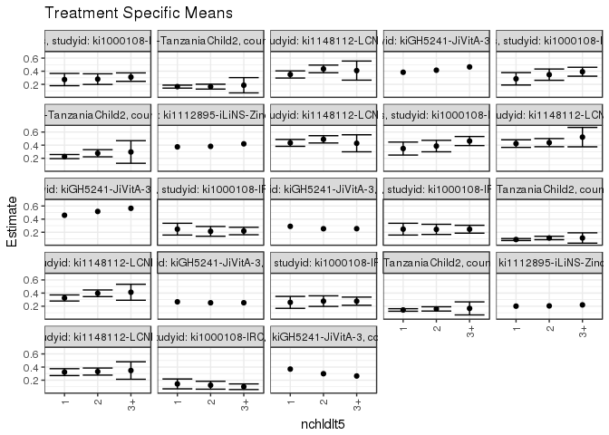

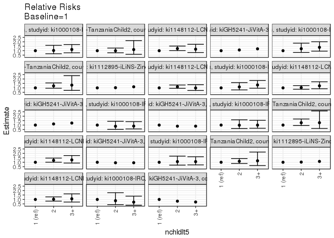

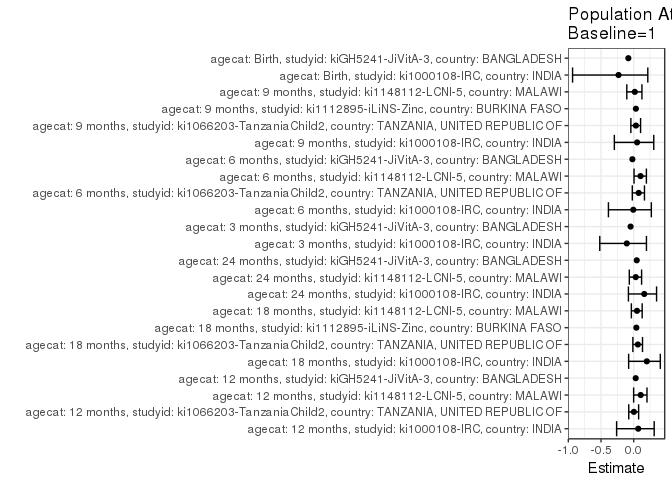

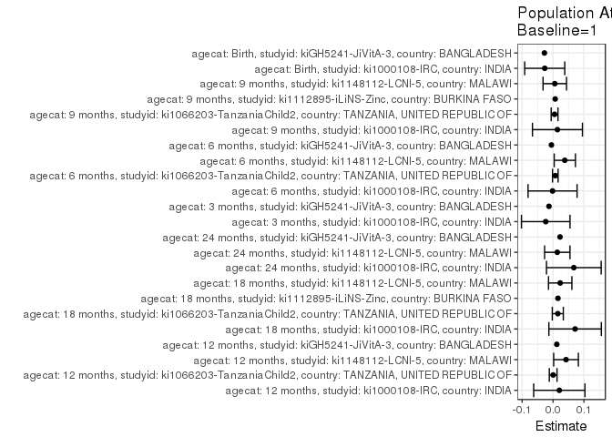

## Results Table

### Parameter: TSM

| agecat | studyid | country | intervention_level | baseline_level | estimate | ci_lower | ci_upper |
| --- | --- | --- | --- | --- | --- | --- | --- |
| Birth | ki1000108-IRC | INDIA | 1 | NA | 0.1428571 | 0.0679288 | 0.2177855 |
| Birth | ki1000108-IRC | INDIA | 2 | NA | 0.1228070 | 0.0624795 | 0.1831345 |
| Birth | ki1000108-IRC | INDIA | 3+ | NA | 0.1000000 | 0.0572877 | 0.1427123 |
| Birth | kiGH5241-JiVitA-3 | BANGLADESH | 1 | NA | 0.3691130 | NA | NA |
| Birth | kiGH5241-JiVitA-3 | BANGLADESH | 2 | NA | 0.2985075 | NA | NA |
| Birth | kiGH5241-JiVitA-3 | BANGLADESH | 3+ | NA | 0.2635983 | NA | NA |
| 3 months | ki1000108-IRC | INDIA | 1 | NA | 0.2471910 | 0.1574593 | 0.3369227 |
| 3 months | ki1000108-IRC | INDIA | 2 | NA | 0.2136752 | 0.1393104 | 0.2880400 |
| 3 months | ki1000108-IRC | INDIA | 3+ | NA | 0.2189055 | 0.1616701 | 0.2761408 |
| 3 months | kiGH5241-JiVitA-3 | BANGLADESH | 1 | NA | 0.2899809 | NA | NA |
| 3 months | kiGH5241-JiVitA-3 | BANGLADESH | 2 | NA | 0.2537064 | NA | NA |
| 3 months | kiGH5241-JiVitA-3 | BANGLADESH | 3+ | NA | 0.2545455 | NA | NA |
| 6 months | ki1000108-IRC | INDIA | 1 | NA | 0.2471910 | 0.1574593 | 0.3369227 |
| 6 months | ki1000108-IRC | INDIA | 2 | NA | 0.2436975 | 0.1664682 | 0.3209268 |
| 6 months | ki1000108-IRC | INDIA | 3+ | NA | 0.2462312 | 0.1863009 | 0.3061614 |
| 6 months | ki1066203-TanzaniaChild2 | TANZANIA, UNITED REPUBLIC OF | 1 | NA | 0.0891445 | 0.0741661 | 0.1041229 |
| 6 months | ki1066203-TanzaniaChild2 | TANZANIA, UNITED REPUBLIC OF | 2 | NA | 0.1128748 | 0.0868219 | 0.1389276 |
| 6 months | ki1066203-TanzaniaChild2 | TANZANIA, UNITED REPUBLIC OF | 3+ | NA | 0.1129032 | 0.0341083 | 0.1916982 |
| 6 months | ki1148112-LCNI-5 | MALAWI | 1 | NA | 0.3256410 | 0.2791040 | 0.3721781 |
| 6 months | ki1148112-LCNI-5 | MALAWI | 2 | NA | 0.3966480 | 0.3459417 | 0.4473544 |
| 6 months | ki1148112-LCNI-5 | MALAWI | 3+ | NA | 0.4126984 | 0.2910538 | 0.5343430 |
| 6 months | kiGH5241-JiVitA-3 | BANGLADESH | 1 | NA | 0.2668403 | NA | NA |
| 6 months | kiGH5241-JiVitA-3 | BANGLADESH | 2 | NA | 0.2521802 | NA | NA |
| 6 months | kiGH5241-JiVitA-3 | BANGLADESH | 3+ | NA | 0.2526882 | NA | NA |
| 9 months | ki1000108-IRC | INDIA | 1 | NA | 0.2584270 | 0.1673658 | 0.3494881 |
| 9 months | ki1000108-IRC | INDIA | 2 | NA | 0.2773109 | 0.1967790 | 0.3578428 |
| 9 months | ki1000108-IRC | INDIA | 3+ | NA | 0.2763819 | 0.2141712 | 0.3385926 |
| 9 months | ki1066203-TanzaniaChild2 | TANZANIA, UNITED REPUBLIC OF | 1 | NA | 0.1427426 | 0.1233217 | 0.1621635 |
| 9 months | ki1066203-TanzaniaChild2 | TANZANIA, UNITED REPUBLIC OF | 2 | NA | 0.1586639 | 0.1259354 | 0.1913924 |
| 9 months | ki1066203-TanzaniaChild2 | TANZANIA, UNITED REPUBLIC OF | 3+ | NA | 0.1666667 | 0.0672391 | 0.2660943 |
| 9 months | ki1112895-iLiNS-Zinc | BURKINA FASO | 1 | NA | 0.2008032 | NA | NA |
| 9 months | ki1112895-iLiNS-Zinc | BURKINA FASO | 2 | NA | 0.2048611 | NA | NA |
| 9 months | ki1112895-iLiNS-Zinc | BURKINA FASO | 3+ | NA | 0.2200957 | NA | NA |
| 9 months | ki1148112-LCNI-5 | MALAWI | 1 | NA | 0.3225806 | 0.2705035 | 0.3746578 |
| 9 months | ki1148112-LCNI-5 | MALAWI | 2 | NA | 0.3310811 | 0.2774288 | 0.3847333 |
| 9 months | ki1148112-LCNI-5 | MALAWI | 3+ | NA | 0.3469388 | 0.2135605 | 0.4803171 |
| 12 months | ki1000108-IRC | INDIA | 1 | NA | 0.2727273 | 0.1795618 | 0.3658928 |
| 12 months | ki1000108-IRC | INDIA | 2 | NA | 0.2796610 | 0.1985785 | 0.3607435 |
| 12 months | ki1000108-IRC | INDIA | 3+ | NA | 0.3100000 | 0.2458238 | 0.3741762 |
| 12 months | ki1066203-TanzaniaChild2 | TANZANIA, UNITED REPUBLIC OF | 1 | NA | 0.1650198 | 0.1421419 | 0.1878976 |
| 12 months | ki1066203-TanzaniaChild2 | TANZANIA, UNITED REPUBLIC OF | 2 | NA | 0.1644909 | 0.1273505 | 0.2016312 |
| 12 months | ki1066203-TanzaniaChild2 | TANZANIA, UNITED REPUBLIC OF | 3+ | NA | 0.1860465 | 0.0696941 | 0.3023990 |
| 12 months | ki1148112-LCNI-5 | MALAWI | 1 | NA | 0.3501684 | 0.2958732 | 0.4044635 |
| 12 months | ki1148112-LCNI-5 | MALAWI | 2 | NA | 0.4347826 | 0.3762511 | 0.4933141 |
| 12 months | ki1148112-LCNI-5 | MALAWI | 3+ | NA | 0.4090909 | 0.2636977 | 0.5544842 |
| 12 months | kiGH5241-JiVitA-3 | BANGLADESH | 1 | NA | 0.3840206 | NA | NA |
| 12 months | kiGH5241-JiVitA-3 | BANGLADESH | 2 | NA | 0.4153395 | NA | NA |
| 12 months | kiGH5241-JiVitA-3 | BANGLADESH | 3+ | NA | 0.4654088 | NA | NA |
| 18 months | ki1000108-IRC | INDIA | 1 | NA | 0.2840909 | 0.1897498 | 0.3784321 |
| 18 months | ki1000108-IRC | INDIA | 2 | NA | 0.3474576 | 0.2614377 | 0.4334776 |
| 18 months | ki1000108-IRC | INDIA | 3+ | NA | 0.3919598 | 0.3240480 | 0.4598716 |
| 18 months | ki1066203-TanzaniaChild2 | TANZANIA, UNITED REPUBLIC OF | 1 | NA | 0.2260870 | 0.1948600 | 0.2573139 |
| 18 months | ki1066203-TanzaniaChild2 | TANZANIA, UNITED REPUBLIC OF | 2 | NA | 0.2769231 | 0.2225034 | 0.3313427 |
| 18 months | ki1066203-TanzaniaChild2 | TANZANIA, UNITED REPUBLIC OF | 3+ | NA | 0.2962963 | 0.1239720 | 0.4686206 |
| 18 months | ki1112895-iLiNS-Zinc | BURKINA FASO | 1 | NA | 0.3743590 | NA | NA |
| 18 months | ki1112895-iLiNS-Zinc | BURKINA FASO | 2 | NA | 0.3819742 | NA | NA |
| 18 months | ki1112895-iLiNS-Zinc | BURKINA FASO | 3+ | NA | 0.4201183 | NA | NA |
| 18 months | ki1148112-LCNI-5 | MALAWI | 1 | NA | 0.4347826 | 0.3824362 | 0.4871290 |
| 18 months | ki1148112-LCNI-5 | MALAWI | 2 | NA | 0.4888179 | 0.4334011 | 0.5442347 |
| 18 months | ki1148112-LCNI-5 | MALAWI | 3+ | NA | 0.4285714 | 0.2988681 | 0.5582747 |
| 24 months | ki1000108-IRC | INDIA | 1 | NA | 0.3483146 | 0.2492110 | 0.4474182 |
| 24 months | ki1000108-IRC | INDIA | 2 | NA | 0.3865546 | 0.2989555 | 0.4741537 |
| 24 months | ki1000108-IRC | INDIA | 3+ | NA | 0.4626866 | 0.3936723 | 0.5317008 |
| 24 months | ki1148112-LCNI-5 | MALAWI | 1 | NA | 0.4240283 | 0.3664003 | 0.4816563 |
| 24 months | ki1148112-LCNI-5 | MALAWI | 2 | NA | 0.4385246 | 0.3762091 | 0.5008401 |
| 24 months | ki1148112-LCNI-5 | MALAWI | 3+ | NA | 0.5227273 | 0.3750127 | 0.6704418 |
| 24 months | kiGH5241-JiVitA-3 | BANGLADESH | 1 | NA | 0.4588105 | NA | NA |
| 24 months | kiGH5241-JiVitA-3 | BANGLADESH | 2 | NA | 0.5169837 | NA | NA |
| 24 months | kiGH5241-JiVitA-3 | BANGLADESH | 3+ | NA | 0.5648148 | NA | NA |

### Parameter: E(Y)

| agecat | studyid | country | intervention_level | baseline_level | estimate | ci_lower | ci_upper |
| --- | --- | --- | --- | --- | --- | --- | --- |
| Birth | ki1000108-IRC | INDIA | NA | NA | 0.1159794 | 0.0840777 | 0.1478811 |
| Birth | kiGH5241-JiVitA-3 | BANGLADESH | NA | NA | 0.3412454 | NA | NA |
| 3 months | ki1000108-IRC | INDIA | NA | NA | 0.2235872 | 0.1830592 | 0.2641152 |
| 3 months | kiGH5241-JiVitA-3 | BANGLADESH | NA | NA | 0.2768467 | NA | NA |
| 6 months | ki1000108-IRC | INDIA | NA | NA | 0.2457002 | 0.2038248 | 0.2875757 |
| 6 months | ki1066203-TanzaniaChild2 | TANZANIA, UNITED REPUBLIC OF | NA | NA | 0.0965347 | 0.0836528 | 0.1094165 |
| 6 months | ki1148112-LCNI-5 | MALAWI | NA | NA | 0.3637485 | 0.3306185 | 0.3968784 |
| 6 months | kiGH5241-JiVitA-3 | BANGLADESH | NA | NA | 0.2616699 | NA | NA |
| 9 months | ki1000108-IRC | INDIA | NA | NA | 0.2727273 | 0.2294063 | 0.3160482 |
| 9 months | ki1066203-TanzaniaChild2 | TANZANIA, UNITED REPUBLIC OF | NA | NA | 0.1477528 | 0.1312632 | 0.1642424 |
| 9 months | ki1112895-iLiNS-Zinc | BURKINA FASO | NA | NA | 0.2077748 | NA | NA |
| 9 months | ki1148112-LCNI-5 | MALAWI | NA | NA | 0.3282443 | 0.2922558 | 0.3642328 |
| 12 months | ki1000108-IRC | INDIA | NA | NA | 0.2931034 | 0.2487723 | 0.3374346 |
| 12 months | ki1066203-TanzaniaChild2 | TANZANIA, UNITED REPUBLIC OF | NA | NA | 0.1655077 | 0.1462927 | 0.1847226 |
| 12 months | ki1148112-LCNI-5 | MALAWI | NA | NA | 0.3922204 | 0.3536641 | 0.4307768 |
| 12 months | kiGH5241-JiVitA-3 | BANGLADESH | NA | NA | 0.3961950 | NA | NA |
| 18 months | ki1000108-IRC | INDIA | NA | NA | 0.3555556 | 0.3088785 | 0.4022327 |
| 18 months | ki1066203-TanzaniaChild2 | TANZANIA, UNITED REPUBLIC OF | NA | NA | 0.2415558 | 0.2147027 | 0.2684088 |
| 18 months | ki1112895-iLiNS-Zinc | BURKINA FASO | NA | NA | 0.3902848 | NA | NA |
| 18 months | ki1148112-LCNI-5 | MALAWI | NA | NA | 0.4579832 | 0.4214124 | 0.4945540 |
| 24 months | ki1000108-IRC | INDIA | NA | NA | 0.4156479 | 0.3678270 | 0.4634689 |
| 24 months | ki1148112-LCNI-5 | MALAWI | NA | NA | 0.4378284 | 0.3971000 | 0.4785567 |
| 24 months | kiGH5241-JiVitA-3 | BANGLADESH | NA | NA | 0.4814556 | NA | NA |

### Parameter: RR

| agecat | studyid | country | intervention_level | baseline_level | estimate | ci_lower | ci_upper |
| --- | --- | --- | --- | --- | --- | --- | --- |
| Birth | ki1000108-IRC | INDIA | 1 | 1 | 1.0000000 | 1.0000000 | 1.000000 |
| Birth | ki1000108-IRC | INDIA | 2 | 1 | 0.8596491 | 0.4190143 | 1.763655 |
| Birth | ki1000108-IRC | INDIA | 3+ | 1 | 0.7000000 | 0.3559067 | 1.376766 |
| Birth | kiGH5241-JiVitA-3 | BANGLADESH | 1 | 1 | 1.0000000 | NA | NA |
| Birth | kiGH5241-JiVitA-3 | BANGLADESH | 2 | 1 | 0.8087157 | NA | NA |
| Birth | kiGH5241-JiVitA-3 | BANGLADESH | 3+ | 1 | 0.7141399 | NA | NA |
| 3 months | ki1000108-IRC | INDIA | 1 | 1 | 1.0000000 | 1.0000000 | 1.000000 |
| 3 months | ki1000108-IRC | INDIA | 2 | 1 | 0.8644134 | 0.5227814 | 1.429298 |
| 3 months | ki1000108-IRC | INDIA | 3+ | 1 | 0.8855721 | 0.5661557 | 1.385198 |
| 3 months | kiGH5241-JiVitA-3 | BANGLADESH | 1 | 1 | 1.0000000 | NA | NA |
| 3 months | kiGH5241-JiVitA-3 | BANGLADESH | 2 | 1 | 0.8749073 | NA | NA |
| 3 months | kiGH5241-JiVitA-3 | BANGLADESH | 3+ | 1 | 0.8778009 | NA | NA |
| 6 months | ki1000108-IRC | INDIA | 1 | 1 | 1.0000000 | 1.0000000 | 1.000000 |
| 6 months | ki1000108-IRC | INDIA | 2 | 1 | 0.9858671 | 0.6088959 | 1.596223 |
| 6 months | ki1000108-IRC | INDIA | 3+ | 1 | 0.9961169 | 0.6434315 | 1.542121 |
| 6 months | ki1066203-TanzaniaChild2 | TANZANIA, UNITED REPUBLIC OF | 1 | 1 | 1.0000000 | 1.0000000 | 1.000000 |
| 6 months | ki1066203-TanzaniaChild2 | TANZANIA, UNITED REPUBLIC OF | 2 | 1 | 1.2662001 | 0.9517318 | 1.684574 |
| 6 months | ki1066203-TanzaniaChild2 | TANZANIA, UNITED REPUBLIC OF | 3+ | 1 | 1.2665193 | 0.6178144 | 2.596364 |
| 6 months | ki1148112-LCNI-5 | MALAWI | 1 | 1 | 1.0000000 | 1.0000000 | 1.000000 |
| 6 months | ki1148112-LCNI-5 | MALAWI | 2 | 1 | 1.2180531 | 1.0055260 | 1.475500 |
| 6 months | ki1148112-LCNI-5 | MALAWI | 3+ | 1 | 1.2673416 | 0.9133374 | 1.758556 |
| 6 months | kiGH5241-JiVitA-3 | BANGLADESH | 1 | 1 | 1.0000000 | NA | NA |
| 6 months | kiGH5241-JiVitA-3 | BANGLADESH | 2 | 1 | 0.9450604 | NA | NA |
| 6 months | kiGH5241-JiVitA-3 | BANGLADESH | 3+ | 1 | 0.9469639 | NA | NA |
| 9 months | ki1000108-IRC | INDIA | 1 | 1 | 1.0000000 | 1.0000000 | 1.000000 |
| 9 months | ki1000108-IRC | INDIA | 2 | 1 | 1.0730727 | 0.6797108 | 1.694081 |
| 9 months | ki1000108-IRC | INDIA | 3+ | 1 | 1.0694778 | 0.7040163 | 1.624654 |
| 9 months | ki1066203-TanzaniaChild2 | TANZANIA, UNITED REPUBLIC OF | 1 | 1 | 1.0000000 | 1.0000000 | 1.000000 |
| 9 months | ki1066203-TanzaniaChild2 | TANZANIA, UNITED REPUBLIC OF | 2 | 1 | 1.1115386 | 0.8681771 | 1.423117 |
| 9 months | ki1066203-TanzaniaChild2 | TANZANIA, UNITED REPUBLIC OF | 3+ | 1 | 1.1676030 | 0.6332242 | 2.152945 |
| 9 months | ki1112895-iLiNS-Zinc | BURKINA FASO | 1 | 1 | 1.0000000 | NA | NA |
| 9 months | ki1112895-iLiNS-Zinc | BURKINA FASO | 2 | 1 | 1.0202083 | NA | NA |
| 9 months | ki1112895-iLiNS-Zinc | BURKINA FASO | 3+ | 1 | 1.0960766 | NA | NA |
| 9 months | ki1148112-LCNI-5 | MALAWI | 1 | 1 | 1.0000000 | 1.0000000 | 1.000000 |
| 9 months | ki1148112-LCNI-5 | MALAWI | 2 | 1 | 1.0263514 | 0.8164964 | 1.290143 |
| 9 months | ki1148112-LCNI-5 | MALAWI | 3+ | 1 | 1.0755102 | 0.7088090 | 1.631924 |
| 12 months | ki1000108-IRC | INDIA | 1 | 1 | 1.0000000 | 1.0000000 | 1.000000 |
| 12 months | ki1000108-IRC | INDIA | 2 | 1 | 1.0254237 | 0.6551104 | 1.605063 |
| 12 months | ki1000108-IRC | INDIA | 3+ | 1 | 1.1366667 | 0.7623570 | 1.694759 |
| 12 months | ki1066203-TanzaniaChild2 | TANZANIA, UNITED REPUBLIC OF | 1 | 1 | 1.0000000 | 1.0000000 | 1.000000 |
| 12 months | ki1066203-TanzaniaChild2 | TANZANIA, UNITED REPUBLIC OF | 2 | 1 | 0.9967949 | 0.7647812 | 1.299195 |
| 12 months | ki1066203-TanzaniaChild2 | TANZANIA, UNITED REPUBLIC OF | 3+ | 1 | 1.1274198 | 0.5941373 | 2.139363 |
| 12 months | ki1148112-LCNI-5 | MALAWI | 1 | 1 | 1.0000000 | 1.0000000 | 1.000000 |
| 12 months | ki1148112-LCNI-5 | MALAWI | 2 | 1 | 1.2416388 | 1.0111525 | 1.524663 |
| 12 months | ki1148112-LCNI-5 | MALAWI | 3+ | 1 | 1.1682692 | 0.7927613 | 1.721644 |
| 12 months | kiGH5241-JiVitA-3 | BANGLADESH | 1 | 1 | 1.0000000 | NA | NA |
| 12 months | kiGH5241-JiVitA-3 | BANGLADESH | 2 | 1 | 1.0815552 | NA | NA |
| 12 months | kiGH5241-JiVitA-3 | BANGLADESH | 3+ | 1 | 1.2119370 | NA | NA |
| 18 months | ki1000108-IRC | INDIA | 1 | 1 | 1.0000000 | 1.0000000 | 1.000000 |
| 18 months | ki1000108-IRC | INDIA | 2 | 1 | 1.2230508 | 0.8082695 | 1.850686 |
| 18 months | ki1000108-IRC | INDIA | 3+ | 1 | 1.3796985 | 0.9486664 | 2.006572 |
| 18 months | ki1066203-TanzaniaChild2 | TANZANIA, UNITED REPUBLIC OF | 1 | 1 | 1.0000000 | 1.0000000 | 1.000000 |
| 18 months | ki1066203-TanzaniaChild2 | TANZANIA, UNITED REPUBLIC OF | 2 | 1 | 1.2248521 | 0.9633117 | 1.557401 |
| 18 months | ki1066203-TanzaniaChild2 | TANZANIA, UNITED REPUBLIC OF | 3+ | 1 | 1.3105413 | 0.7208459 | 2.382643 |
| 18 months | ki1112895-iLiNS-Zinc | BURKINA FASO | 1 | 1 | 1.0000000 | NA | NA |
| 18 months | ki1112895-iLiNS-Zinc | BURKINA FASO | 2 | 1 | 1.0203422 | NA | NA |
| 18 months | ki1112895-iLiNS-Zinc | BURKINA FASO | 3+ | 1 | 1.1222339 | NA | NA |
| 18 months | ki1148112-LCNI-5 | MALAWI | 1 | 1 | 1.0000000 | 1.0000000 | 1.000000 |
| 18 months | ki1148112-LCNI-5 | MALAWI | 2 | 1 | 1.1242811 | 0.9529163 | 1.326463 |
| 18 months | ki1148112-LCNI-5 | MALAWI | 3+ | 1 | 0.9857143 | 0.7117001 | 1.365228 |
| 24 months | ki1000108-IRC | INDIA | 1 | 1 | 1.0000000 | 1.0000000 | 1.000000 |
| 24 months | ki1000108-IRC | INDIA | 2 | 1 | 1.1097858 | 0.7713798 | 1.596651 |
| 24 months | ki1000108-IRC | INDIA | 3+ | 1 | 1.3283582 | 0.9633801 | 1.831609 |
| 24 months | ki1148112-LCNI-5 | MALAWI | 1 | 1 | 1.0000000 | 1.0000000 | 1.000000 |
| 24 months | ki1148112-LCNI-5 | MALAWI | 2 | 1 | 1.0341872 | 0.8495785 | 1.258910 |
| 24 months | ki1148112-LCNI-5 | MALAWI | 3+ | 1 | 1.2327652 | 0.9009483 | 1.686789 |
| 24 months | kiGH5241-JiVitA-3 | BANGLADESH | 1 | 1 | 1.0000000 | NA | NA |
| 24 months | kiGH5241-JiVitA-3 | BANGLADESH | 2 | 1 | 1.1267914 | NA | NA |
| 24 months | kiGH5241-JiVitA-3 | BANGLADESH | 3+ | 1 | 1.2310416 | NA | NA |

### Parameter: PAR

| agecat | studyid | country | intervention_level | baseline_level | estimate | ci_lower | ci_upper |
| --- | --- | --- | --- | --- | --- | --- | --- |
| Birth | ki1000108-IRC | INDIA | 1 | NA | -0.0268778 | -0.0916934 | 0.0379379 |
| Birth | kiGH5241-JiVitA-3 | BANGLADESH | 1 | NA | -0.0278676 | NA | NA |
| 3 months | ki1000108-IRC | INDIA | 1 | NA | -0.0236038 | -0.1021715 | 0.0549639 |
| 3 months | kiGH5241-JiVitA-3 | BANGLADESH | 1 | NA | -0.0131341 | NA | NA |
| 6 months | ki1000108-IRC | INDIA | 1 | NA | -0.0014908 | -0.0807619 | 0.0777804 |
| 6 months | ki1066203-TanzaniaChild2 | TANZANIA, UNITED REPUBLIC OF | 1 | NA | 0.0073902 | -0.0016270 | 0.0164074 |
| 6 months | ki1148112-LCNI-5 | MALAWI | 1 | NA | 0.0381074 | 0.0037508 | 0.0724640 |
| 6 months | kiGH5241-JiVitA-3 | BANGLADESH | 1 | NA | -0.0051705 | NA | NA |
| 9 months | ki1000108-IRC | INDIA | 1 | NA | 0.0143003 | -0.0665842 | 0.0951848 |
| 9 months | ki1066203-TanzaniaChild2 | TANZANIA, UNITED REPUBLIC OF | 1 | NA | 0.0050102 | -0.0059723 | 0.0159927 |
| 9 months | ki1112895-iLiNS-Zinc | BURKINA FASO | 1 | NA | 0.0069716 | NA | NA |
| 9 months | ki1148112-LCNI-5 | MALAWI | 1 | NA | 0.0056636 | -0.0322849 | 0.0436121 |
| 12 months | ki1000108-IRC | INDIA | 1 | NA | 0.0203762 | -0.0625840 | 0.1033363 |
| 12 months | ki1066203-TanzaniaChild2 | TANZANIA, UNITED REPUBLIC OF | 1 | NA | 0.0004879 | -0.0119992 | 0.0129749 |
| 12 months | ki1148112-LCNI-5 | MALAWI | 1 | NA | 0.0420521 | 0.0020961 | 0.0820081 |
| 12 months | kiGH5241-JiVitA-3 | BANGLADESH | 1 | NA | 0.0121744 | NA | NA |
| 18 months | ki1000108-IRC | INDIA | 1 | NA | 0.0714646 | -0.0134544 | 0.1563837 |
| 18 months | ki1066203-TanzaniaChild2 | TANZANIA, UNITED REPUBLIC OF | 1 | NA | 0.0154688 | -0.0023878 | 0.0333255 |
| 18 months | ki1112895-iLiNS-Zinc | BURKINA FASO | 1 | NA | 0.0159258 | NA | NA |
| 18 months | ki1148112-LCNI-5 | MALAWI | 1 | NA | 0.0232006 | -0.0146085 | 0.0610097 |
| 24 months | ki1000108-IRC | INDIA | 1 | NA | 0.0673333 | -0.0211764 | 0.1558430 |
| 24 months | ki1148112-LCNI-5 | MALAWI | 1 | NA | 0.0138001 | -0.0272837 | 0.0548839 |
| 24 months | kiGH5241-JiVitA-3 | BANGLADESH | 1 | NA | 0.0226451 | NA | NA |

### Parameter: PAF

| agecat | studyid | country | intervention_level | baseline_level | estimate | ci_lower | ci_upper |
| --- | --- | --- | --- | --- | --- | --- | --- |
| Birth | ki1000108-IRC | INDIA | 1 | NA | -0.2317460 | -0.9350634 | 0.2159439 |
| Birth | kiGH5241-JiVitA-3 | BANGLADESH | 1 | NA | -0.0816645 | NA | NA |
| 3 months | ki1000108-IRC | INDIA | 1 | NA | -0.1055686 | -0.5189670 | 0.1953203 |
| 3 months | kiGH5241-JiVitA-3 | BANGLADESH | 1 | NA | -0.0474419 | NA | NA |
| 6 months | ki1000108-IRC | INDIA | 1 | NA | -0.0060674 | -0.3864361 | 0.2699471 |
| 6 months | ki1066203-TanzaniaChild2 | TANZANIA, UNITED REPUBLIC OF | 1 | NA | 0.0765544 | -0.0212450 | 0.1649881 |
| 6 months | ki1148112-LCNI-5 | MALAWI | 1 | NA | 0.1047631 | 0.0051365 | 0.1944131 |
| 6 months | kiGH5241-JiVitA-3 | BANGLADESH | 1 | NA | -0.0197595 | NA | NA |
| 9 months | ki1000108-IRC | INDIA | 1 | NA | 0.0524345 | -0.2957543 | 0.3070596 |
| 9 months | ki1066203-TanzaniaChild2 | TANZANIA, UNITED REPUBLIC OF | 1 | NA | 0.0339095 | -0.0432858 | 0.1053929 |
| 9 months | ki1112895-iLiNS-Zinc | BURKINA FASO | 1 | NA | 0.0335536 | NA | NA |
| 9 months | ki1148112-LCNI-5 | MALAWI | 1 | NA | 0.0172543 | -0.1054304 | 0.1263231 |
| 12 months | ki1000108-IRC | INDIA | 1 | NA | 0.0695187 | -0.2612281 | 0.3135299 |
| 12 months | ki1066203-TanzaniaChild2 | TANZANIA, UNITED REPUBLIC OF | 1 | NA | 0.0029478 | -0.0754265 | 0.0756105 |
| 12 months | ki1148112-LCNI-5 | MALAWI | 1 | NA | 0.1072154 | -0.0007885 | 0.2035637 |
| 12 months | kiGH5241-JiVitA-3 | BANGLADESH | 1 | NA | 0.0307282 | NA | NA |
| 18 months | ki1000108-IRC | INDIA | 1 | NA | 0.2009943 | -0.0771426 | 0.4073115 |
| 18 months | ki1066203-TanzaniaChild2 | TANZANIA, UNITED REPUBLIC OF | 1 | NA | 0.0640383 | -0.0127330 | 0.1349899 |
| 18 months | ki1112895-iLiNS-Zinc | BURKINA FASO | 1 | NA | 0.0408055 | NA | NA |
| 18 months | ki1148112-LCNI-5 | MALAWI | 1 | NA | 0.0506582 | -0.0356587 | 0.1297810 |
| 24 months | ki1000108-IRC | INDIA | 1 | NA | 0.1619960 | -0.0806502 | 0.3501592 |
| 24 months | ki1148112-LCNI-5 | MALAWI | 1 | NA | 0.0315194 | -0.0670380 | 0.1209735 |
| 24 months | kiGH5241-JiVitA-3 | BANGLADESH | 1 | NA | 0.0470346 | NA | NA |